# M2.891_20251_PEC1-Enunciado

[figure not shown]

M2.891 · Aprendizaje automático · PEC1

2025-1 · Máster universitario en Ciencia de datos (Data science)

Estudios de Informática, Multimedia y Telecomunicación

**PEC 1: Preparación de datos**

El objetivo principal de esta primera PEC es que os familiaricéis con el entorno de trabajo que vais a utilizar en el resto de actividades de la asignatura. Dicho entorno estará formado por un conjunto de dependencias a los módulos de Python necesarios para poder ejecutar de forma correcta el código que resuelve vuestra PEC. Estas dependencias las gestionaremos gracias a la ayuda de Anaconda, que, entre otras cosas, nos provee de un gestor de entornos virtuales para Python.

Otra de las herramientas fundamentales del que será vuestro nuevo entorno de trabajo será Jupyter, que os permitirá trabajar con Notebooks (ficheros *.ipynb), como el presente enunciado, y donde podréis ejecutar vuestro código celda a celda, mostrando los resultados intermedios que necesitéis para comprender correctamente qué es lo que estáis haciendo en cada momento.

En esta primera PEC, otro de los aspectos imprescindibles que vamos a cubrir, tal y como adelanta su título, es el de la preparación de los datos. En esta PEC aprenderemos a cargar distintos conjuntos de datos o *datasets*, los combinaremos y nos ayudaremos de herramientas de visualización para comprender mejor cómo se distribuye el dato, con el objetivo de entender cómo podemos sacarle partido. Además, nos habituaremos a trabajar con conjuntos de entrenamiento y test para confirmar si las conclusiones que sacamos sobre una parte de las muestras se pueden generalizar y extrapolar al resto.

En resumen, en esta actividad veremos cómo aplicar diferentes técnicas para la carga y preparación de datos siguiendo los pasos listados a continuación:

1. Carga y combinación de los distintos conjuntos de datos (1.5 puntos)  
   1.1. Accidentes gestionados por la Guardia Urbana en la ciudad de Barcelona  
   1.2. Climatologías diarias (AEMET)
2. Análisis de los datos (3 puntos)  
   2.1. Análisis estadístico básico  
   2.2. Análisis exploratorio de los datos
3. Preprocesado de los datos (1 punto)
4. Reducción de la dimensionalidad (2 puntos)
5. Conjuntos desbalanceados de datos (1.5 puntos)
6. Búsqueda y combinación de nuevos conjuntos de datos (1 punto)

**Importante:** cada uno de los ejercicios puede suponer varios minutos de ejecución, por lo que la entrega debe hacerse en formato notebook y en formato html, donde se vea el código, los resultados y comentarios de cada ejercicio. Se puede exportar el notebook a html desde el menú File $\to$ Download as $\to$ HTML.

**Importante:** existe un tipo de celda especial para albergar texto. Este tipo de celda os será muy útil para responder a las diferentes preguntas teóricas planteadas a lo largo de cada PEC. Para cambiar el tipo de celda a este tipo, elegid en el menú: Cell $\to$ Cell Type $\to$ Markdown.

**Importante:** la solución planteada no debe utilizar métodos, funciones o parámetros declarados "deprecated" en futuras versiones.

**Importante:** es conveniente que utilicéis una semilla con un valor fijo (en este Notebook se os propone la variable *seed* inicializada a 100) en todos aquellos métodos o funciones que contengan alguna componente aleatoria para aseguraros de que obtendréis siempre el mismo resultado en las distintas ejecuciones de vuestro código.

**Importante:** no olvidéis poner vuestro nombre y apellidos en la siguiente celda.

**Nombre y apellidos:** Jorge Solán Morote

### **Aclaración** todos los análisis se han realizado sin contar el tipo de vehículo, ese atributo es el extra que se ha metido en el ejercicio final. En ese apartado se explica de donde sacar estos nuevos datos y cómo mergearlos, para ver el original simplemente ejecutar todo y estos datos no estarán, se mantendrá esta versión en el HTML enviado.

Para la realización de la actividad necesitaremos importar los siguientes módulos:

```python
import numpy as np
import pandas as pd

from sklearn import preprocessing
from sklearn.manifold import TSNE
from sklearn.decomposition import PCA
from sklearn.model_selection import train_test_split
from imblearn.over_sampling import RandomOverSampler, SMOTE, ADASYN

import matplotlib.pyplot as plt
import seaborn as sns

pd.set_option('display.max_columns', None)
seed = 100

%matplotlib inline
```

# Carga y combinación de los distintos conjuntos de datos (1.5 puntos)

En esta PEC trabajaremos con un conjunto de datos en el que cada muestra representará uno de los accidentes gestionados por la Guardia Urbana en la ciudad de Barcelona. Este conjunto de datos incorpora el número de lesionados segun gravedad, el número de vehículos y el punto de impacto. Por otro lado, queremos enriquecer dicho conjunto de datos añadiéndole nuevos atributos descriptivos y esto lo haremos utilizando un segundo *dataset*, en el que cada muestra será la información climatológica de un día.

Comencemos con la carga de datos:

## Accidentes gestionados por la Guardia Urbana en la ciudad de Barcelona

El primer conjunto de datos, que además es el principal, está disponible dentro del servicio de datos abiertos del Ajuntament de Barcelona: [Open Data BCN](https://opendata-ajuntament.barcelona.cat/es/).

En el enlace https://opendata-ajuntament.barcelona.cat/data/es/dataset/accidents-gu-bcn tenéis accesible tanto el mencionado *dataset* (separado por año) como toda la información relevante para comprender mejor con qué tipo de dato vamos a trabajar. Como puede comprobarse en la descripción, tenemos tanto el código de la calle donde ha sucedido el accidente como su nombre, pero no disponemos del tipo de vía donde sucede, algo que podría resultarnos útil. Por este motivo haremos uso de un archivo complementario que encontraremos en el siguiente enlace https://opendata-ajuntament.barcelona.cat/data/es/dataset/carrerer.

En el desarrollo de esta PEC y con la intención de ayudar a evitar todo tipo de accidentes, queremos averiguar qué atributos descriptivos nos dan más información acerca de la gravedad del accidente. En el conjunto de datos facilitado esta información viene desglosada en diferentes columnas referentes al número y tipo de víctimas. Para nuestro propósito, vamos a combinar la información que nos dan estas columnas en una única columna que llamaremos "gravedad" y que será nuestra variable objetivo.

En primer lugar, deberéis cargar y procesar en el Notebook los ficheros que conformarán el cuerpo del conjunto de datos con el que trabajaremos durante el resto de la actividad. Para ello podéis descargarlos manualmente de los enlaces referidos previamente o utilizar los ficheros que os facilitamos en el enunciado: "2023_accidents_gu_bcn.csv", "2024_accidents_gu_bcn.csv" y "carrerer.csv".

**Ejercicio:** con la ayuda de *pandas*, cargad por separado los distintos ficheros que conforman el conjunto de datos de accidentes. Para ello:

- Concatenad en el mismo *DataFrame* los accidentes de los años 2023 y 2024.
- Generad una nueva columna llamada "gravedad" que tomará los valores numéricos 3, 2, 1 ó 0 en función de si hay muertos, heridos graves, leves o ningún tipo de víctima respectivamente.
- Incorporad a dicho *DataFrame* la información del tipo de vía que se encuentra en el callejero utilizando para cruzarla el código de la calle.
- Quedaros con las columnas referentes a la latitud y longitud en sistema WGS84, tipo de vía, día de la semana, fecha y hora, así como con la nueva columna que indicará la gravedad del accidente.

Posteriormente, mostrad:

- El número y nombre de los atributos descriptivos (variables que podrían ser usadas para predecir la variable objetivo "y").
- El número de filas (muestras) del conjunto de datos.
- Verificad si hay o no "missing values" y en qué columnas. En caso de exisitir, imputarlos utilizando 0 o el valor que creáis más conveniente.

```python
# Carga de archivos en DataFrames
df_2023 = pd.read_csv("./data/2023_accidents_gu_bcn.csv")
df_2024 = pd.read_csv("./data/2024_accidents_gu_bcn.csv")
df_carrerer = pd.read_csv("./data/carrerer.csv")

# Concatenar en un solo DataFrame información de accidentes
df_concat = pd.concat([df_2023, df_2024])

# Incorporar información sobre la gravedad del accidente
df_concat["Gravedad"] = np.select(
    [
        df_concat["Numero_morts"] > 0,
        df_concat["Numero_lesionats_greus"] > 0,
        df_concat["Numero_lesionats_lleus"] > 0
    ],
    [3, 2, 1],
    default=0
)

# Incorporar el tipo de vía
df_concat["Codi_carrer"].astype(str) # Transformar a str como en carrerer
mapping = df_carrerer.set_index('codi_via')['tipus_via']
df_concat['tipus_via'] = df_concat['Codi_carrer'].map(mapping)

# Crear la fecha a partir del día mes y año para facilitar tarea de después
df_concat['Fecha'] = pd.to_datetime({
    'year': df_concat['NK_Any'],
    'month': df_concat['Mes_any'],
    'day': df_concat['Dia_mes']
})

# Crear el DataFrame que usaremos en adelante
df = df_concat[[
        'Longitud_WGS84',
        'Latitud_WGS84',
        'tipus_via',
        'Descripcio_dia_setmana',
        'Fecha',
        'Hora_dia',
        'Gravedad'
    ]].copy()
```

```python
# Variable a predecir es gravedad, el resto son los atributos descriptivos
atributos_descriptivos = df.drop(columns=['Gravedad'])
numero_atributos = len(atributos_descriptivos.columns)

print("Número de atributos descriptivos:", numero_atributos)
print("Nombre de los atributos descriptivos:", list(atributos_descriptivos.columns))

print("="*70)

# Número de filas(datos) del DataFrame
n_filas = len(df)
print(f"Número de filas del DataFrame: {n_filas}")

print("="*70)

#Valores nulos
nan_value = df.isnull().sum()
print("Valores nulos del data frame:")
print(nan_value)
```

[output not shown]

Vemos que solo hay valores nulos en el tipo de vía, para rellenar estos valores se decide coger la moda del DataFrame la cual corresponde a "C", calle, dado que represneta el valor más frecuente del tipo de vía. También podríamos justificar que el resto de tipos como avenida, pase, plaza, son especificaciones, menos comunes de una calle por lo que usar este valor mantiene coherencia con los datos

```python
# Calcular el valor más frecuente (moda) de la columna
moda_tipus_via = df['tipus_via'].mode()[0]

# Rellenar los valores nulos con esa moda
df.fillna({'tipus_via' : moda_tipus_via}, inplace=True)
```

**Pregunta:** ¿el conjunto de datos propuesto es un problema de aprendizaje automático supervisado o no?, en el caso de serlo, ¿de qué tipo de aprendizaje supervisado estaríamos hablando?

Sí, el conjunto de datos es un problema de **aprendizaje supervisado** ya que tenemos una variable, en este caso la gravedad del accidente, la cual queremos predecir según unos atributos descriptivos.

El tipo de aprendizaje supervisado sería **clasificación multiclase**, ya que la variable "Gravedad" es **discreta y ordinal** con 4 categorías (0=sin víctimas, 1=con lesionados leves, 2=con lesiones graves, 3=con víctimas mortales).

## Climatologías diarias (AEMET)

El segundo conjunto de datos complementa al conjunto de datos inicial con la información de las condiciones meteorológicas de cada día.

La combinación de ambos conjuntos de datos la haremos mediante su fecha. En nuestro caso, partiendo de la premisa de que condiciones meteorológicas menos favorables pueden conducir a un mayor riesgo de accidentes esperamos enriquecer el conjunto de datos original con información muy valiosa.

El conjunto de datos se ha obtenido del siguiente enlace: https://opendata.aemet.es/centrodedescargas/productosAEMET?, aunque os lo facilitamos junto al enunciado en el fichero "opendata_aemet_es.csv".

NOTA: como podréis comprobar más adelante, existen muchísimos días donde no hay precipitaciones y otros tantos donde las precipitaciones varían en cantidad, dificultando el análisis de dicha variable y no quedando claro si cuando llueve suceden más accidentes de un tipo o de otro. Es por esto que os pediremos que generéis una nueva columna en función de las precipitaciones en la que reduciréis su dominio continuo a un pequeño número de categorías.

**Ejercicio:** complementa la información del conjunto de datos de accidentes cargado en la sección anterior con el nuevo conjunto de datos:

- Cargad el conjunto de datos con las condiciones meteorológicas con la ayuda de *pandas*.
- Estudiad la distribución de la columna "prec" y decidid algún criterio mediante el cual podáis categorizarla en un reducido número de opciones.
- Incorporad al conjunto de datos de accidentes que habéis preparado en la sección anterior la información metereológica relevante cruzándola a través de la fecha.

NOTA: el nuevo conjunto de datos complementario no dispone de información meteorológica para todos los días de 2023, quedaos sólo con las muestras de accidentes que estén dentro del rango de fechas cubierto por este último *dataset*.

NOTA: podéis eliminar el año del conjunto de datos una vez lo hayáis utilizado para cruzar los accidentes con las condiciones meteorológicas.

Posteriormente, mostrad:

- El número y nombre de los atributos descriptivos (variables que podrían ser usadas para predecir la variable objetivo "y").
- El número de filas (muestras) del conjunto de datos.
- Verificad si hay o no "missing values" y en qué columnas. En caso de exisitir, imputarlos utilizando 0 o el valor que creáis más conveniente.

Sugerencia: separad el conjunto de datos original en las variables "X" (atributos descriptivos) e "y" (variable objetivo), aunque quizá pueda seros de utilidad en algún punto tenerlos también en un único DataFrame combinados.

```python
# Carga del conjunto de la aemet
df_aemet = pd.read_csv("./data/opendata_aemet_es.csv", decimal=",")

#Estudiar el prec y transformar
# Para estudiarlo podemos mirar sus valores únicos y entender lo que nos quiere decir estos valores.
# La variable de precipitación marca la cantidad de Litros recogidos en un día, con lo cual, para categorizarla podemos dividirla en subgrupos según cuanto ha llovido.
# print(df_aemet["prec"].unique())
df_aemet["prec_nivel"] = np.select(
    [
        df_aemet["prec"] > 35,
        df_aemet["prec"] > 25,
        df_aemet["prec"] > 15,
        df_aemet["prec"] > 5,
        df_aemet["prec"] > 0
    ],
    ["Muy Alto", "Alto", "Moderado", "Poco", "Muy Poco"],
    default="Nada"
)

# Convertir la fecha a su formato
df_aemet['fecha'] = pd.to_datetime(df_aemet['fecha'])

# Hacer el merge según la fecha, por eso creaba la anterior fecha, para compararla fácilmente con esta
df = df.merge(
    df_aemet[
        [
            "fecha",
            "prec_nivel",
            "tmed",
            "tmin",
            "tmax",
            "velmedia",
            "racha",
            "hrMedia"
        ]
    ],
    left_on="Fecha",
    right_on="fecha",
    how="inner"
).drop(columns=["fecha"])

# Para eliminar Fecha y dejar solo variables numéricas
# Crear columnas de mes y día
df['mes'] = df['Fecha'].dt.month
df['dia'] = df['Fecha'].dt.day

# Eliminar Fecha
df = df.drop(columns=['Fecha'])
```

```python
x = df.drop(columns=['Gravedad'])
numero_atributos = len(x.columns)

print("Número de atributos descriptivos:", numero_atributos)
print("Nombre de los atributos descriptivos:", list(x.columns))

print("="*70)

n_filas = len(df)
print(f"Número de filas del DataFrame: {n_filas}")

print("="*70)

nan_value = df.isnull().sum()
print("Valores nulos del data frame:")
print(nan_value)
```

```
Número de atributos descriptivos: 15
Nombre de los atributos descriptivos: ['Longitud_WGS84', 'Latitud_WGS84', 'tipus_via', 'Descripcio_dia_setmana', 'Hora_dia', 'Descripcio_tipus_vehicle', 'prec_nivel', 'tmed', 'tmin', 'tmax', 'velmedia', 'racha', 'hrMedia', 'mes', 'dia']
======================================================================
Número de filas del DataFrame: 16193
======================================================================
Valores nulos del data frame:
Longitud_WGS84               0
Latitud_WGS84                0
tipus_via                    0
Descripcio_dia_setmana       0
Hora_dia                     0
Gravedad                     0
Descripcio_tipus_vehicle     0
prec_nivel                   0
tmed                         0
tmin                         0
tmax                         0
velmedia                     0
racha                       49
hrMedia                      0
mes                          0
dia                          0
dtype: int64
```

```python
# Vemos primero cuales tiene valores nulos del primer DataFrame de la aemet
print(df_aemet[df_aemet['racha'].isnull()].index)

# Vemos que en la racha había un valor nulo, como el Dataframe está ordenado por fecha, podemos poner ese valor de racha como la media del día anterior y el siguiente.
medio = (df_aemet.loc[489, 'racha'] + df_aemet.loc[487, 'racha']) / 2
df.fillna({'racha' : medio}, inplace=True)
```

```
Index([488], dtype='int64')
```

```python
# Tras esto podemos ver que no tiene valores nulos
nan_value = df.isnull().sum()
print("Valores nulos del data frame:")
print(nan_value)
```

```
Valores nulos del data frame:
Longitud_WGS84              0
Latitud_WGS84               0
tipus_via                   0
Descripcio_dia_setmana      0
Hora_dia                    0
Gravedad                    0
Descripcio_tipus_vehicle    0
prec_nivel                  0
tmed                        0
tmin                        0
tmax                        0
velmedia                    0
racha                       0
hrMedia                     0
mes                         0
dia                         0
dtype: int64
```

# Análisis de los datos (3 puntos)

En este apartado visualizaremos cada una de las columnas o *features* del dato para comprender mejor qué distribución tiene.

## Análisis estadístico básico

**Ejercicio:** realizad un análisis estadístico básico:

- Variables categóricas:
- Calculad la frecuencia.
- Haced un gráfico de barras para cada variable.
- Variables numéricas:
- Calculad estadísticos descriptivos básicos: media, mediana, desviación estandard, ...
- Haced un histograma para cada variable.

Sugerencia: podéis usar la librería "pandas" y sus funciones "describe" y "value_counts", así como las funciones "bar", "hist" y "hist2d" de *matplotlib* (esta última os vendrá bien para mostrar un mapa de calor combinando las latitudes con las longitudes).

```python
# Separamos en variables para trabajar mejor
categoricas = ["tipus_via", "prec_nivel", "Descripcio_dia_setmana"]
# IGNORAR, es por el ejercicio final
if "Descripcio_tipus_vehicle" in df.columns:
    categoricas.append("Descripcio_tipus_vehicle")


# Filtramos las numéricas excluyendo las categóricas, la Gravedad que es nuestro objetivo y la fecha que es una variable diferente
numericas = [col for col in df.columns if col not in categoricas + ["Gravedad"]]

v_categoricas = df[categoricas]
v_numericas = df[numericas]
```

Variables Categóricas

```
Frecuencias de 'tipus_via':
           Frecuencia  Porcentaje (%)  Relacion
tipus_via
C                7595           46.90     2.617
Av               2329           14.38    28.753
Rda              1482            9.15    82.333
Pg               1210            7.47    14.578
Ctra             1090            6.73    26.585
G.V.              916            5.66   458.000
Pl                605            3.74     1.049
Via               372            2.30    62.000
Rbla              284            1.75    17.750
Trav              225            1.39    75.000
Rier               29            0.18     3.625
Pla                11            0.07     1.571
Camí                8            0.05     0.105
Nus                 7            0.04     7.000
Pas                 6            0.04     0.300
Ptge                5            0.03     0.013
Jard                4            0.02     0.017
Parc                4            0.02     0.060
Plta                3            0.02     0.071
T                   3            0.02     0.231
Bda                 3            0.02     0.130
Viad                2            0.01     2.000
```

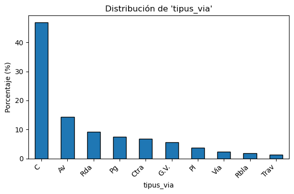

```
Frecuencias de 'prec_nivel':
            Frecuencia  Porcentaje (%)  Relacion
prec_nivel
Nada             12070           74.54    26.239
Muy Poco          2756           17.02    26.757
Poco               778            4.80    35.364
Moderado           266            1.64    24.182
Alto               166            1.03    41.500
Muy Alto           157            0.97    26.167
```

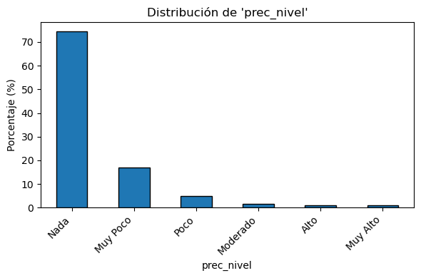

```
Frecuencias de 'Descripcio_dia_setmana':
                        Frecuencia  Porcentaje (%)
Descripcio_dia_setmana
Divendres                     2670           16.49
Dimarts                       2598           16.04
Dijous                        2516           15.54
Dimecres                      2512           15.51
Dilluns                       2463           15.21
Dissabte                      1957           12.09
Diumenge                      1477            9.12
```

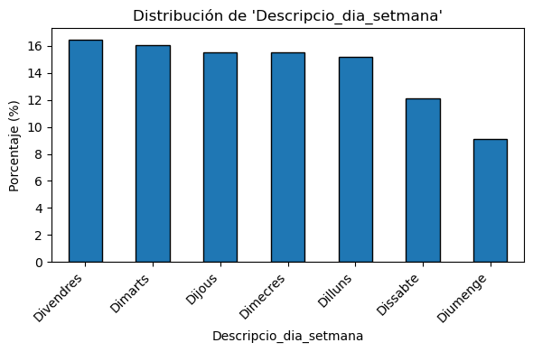

```
Frecuencias de 'Descripcio_tipus_vehicle':
                                     Frecuencia  Porcentaje (%)
Descripcio_tipus_vehicle
Turisme                                    5880           36.31
Motocicleta                                4732           29.22
Furgoneta                                  1078            6.66
Bicicleta                                   840            5.19
Autobús                                     799            4.93
Taxi                                        629            3.88
Veh. mobilitat personal amb motor           626            3.87
Ciclomotor                                  399            2.46
Autobús articulat                           368            2.27
Camió rígid <= 3,5 tones                    211            1.30
Camió rígid > 3,5 tones                     163            1.01
Tot terreny                                 147            0.91
Sense Informar                               90            0.56
Tractor camió                                54            0.33
Altres vehicles amb motor                    46            0.28
Ambulància                                   29            0.18
Tren o tramvia                               26            0.16
Maquinària d'obres i serveis                 18            0.11
Tricicle                                     18            0.11
Autocar                                      15            0.09
Quadricicle < 75 cc                          10            0.06
Autocaravana                                  6            0.04
Pick-up                                       3            0.02
Quadricicle > 75 cc                           2            0.01
Bicicleta pedaleig assistit                   2            0.01
Veh. mobilitat personal sense motor           1            0.01
Altres vehicles sense motor                   1            0.01
```

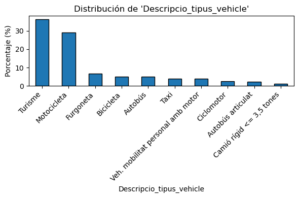

```python
# Frecuencia de las variables categoricas
for col in v_categoricas.columns:
    print(f"\nFrecuencias de '{col}':")

    # Frecuencias absolutas y relativas
    freq_abs = v_categoricas[col].value_counts()
    freq_rel = v_categoricas[col].value_counts(normalize=True) * 100

    if col == 'tipus_via':
        rel = 1 / (df_carrerer["tipus_via"].value_counts() / freq_abs)
    elif col == 'prec_nivel':
        rel = 1 / (df_aemet["prec_nivel"].value_counts() / freq_abs)
    else:
        rel = None

    # Crear tabla alineando índices
    tabla = pd.DataFrame({
        'Frecuencia': freq_abs,
        'Porcentaje (%)': freq_rel.round(2)
    })

    # No añadir relación donde no la haya puesto
    if rel is not None:
        tabla['Relacion'] = rel.round(3)
        # Eliminar filas con NaN en 'Relacion', hay casos en las carreteras
        tabla = tabla.dropna(subset=['Relacion'])

    print(tabla)


    # Gráfico de barras
    plt.figure(figsize=(6, 4))
    freq_rel.head(10).plot(
        kind='bar', edgecolor='black'
    )
    plt.title(f"Distribución de '{col}'")
    plt.ylabel("Porcentaje (%)")
    plt.xlabel(col)
    plt.xticks(rotation=45, ha='right')
    plt.tight_layout()
    plt.show()
```

Como aclaración, he añadido la columna de relación que relaciona el número de datos con el número de accidentes.

Con esto tenemos un "dato" de qué tipo de vía es más propensa a tener accidentes, aunque habría que relacionarlo también con cómo de largo es, por ejemplo.

**Análisis:** comentad los resultados. Variables categóricas.

Variables numéricas

```
Estadísticos descriptivos:

                 mean    std    min  mediana    max
Longitud_WGS84   2.16   0.02   2.09     2.16   2.22
Latitud_WGS84   41.40   0.02  41.32    41.40  41.47
Hora_dia        13.70   5.38   0.00    14.00  23.00
tmed            17.84   5.06   7.50    17.30  30.40
tmin            14.75   5.37   3.90    14.20  25.90
tmax            20.93   4.91  10.10    20.40  35.20
velmedia         3.56   1.35   0.80     3.30   8.30
racha            9.38   3.11   3.60     8.90  21.70
hrMedia         77.70  10.87  37.00    80.00  93.00
mes              6.53   3.46   1.00     6.00  12.00
dia             15.54   8.74   1.00    16.00  31.00
```

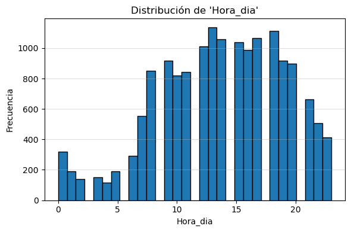

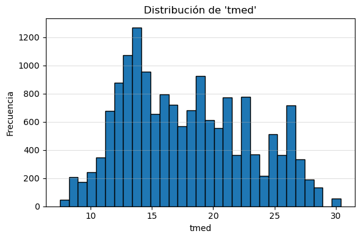

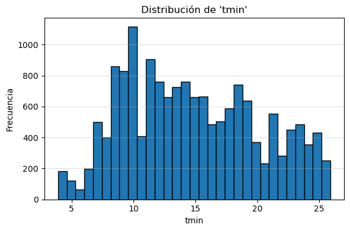

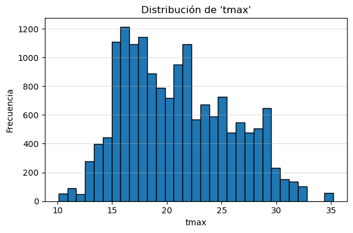

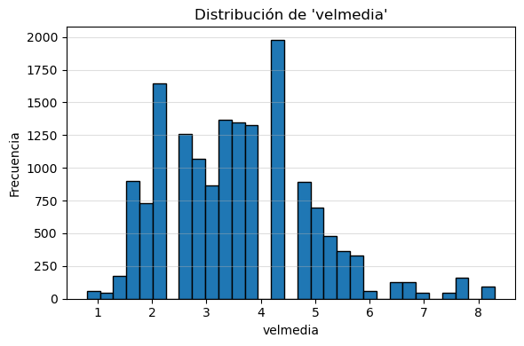

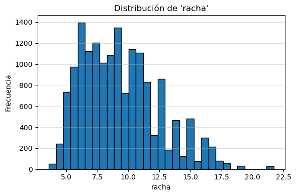

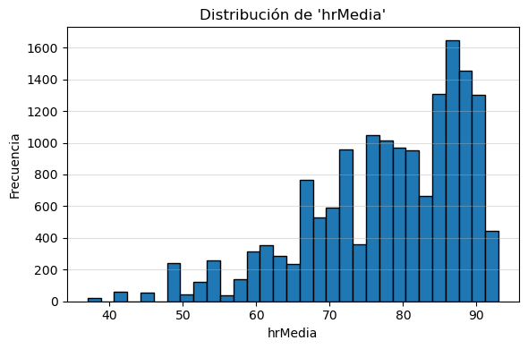

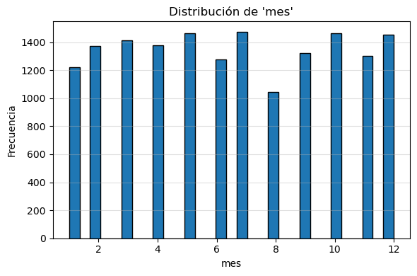

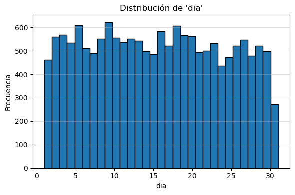

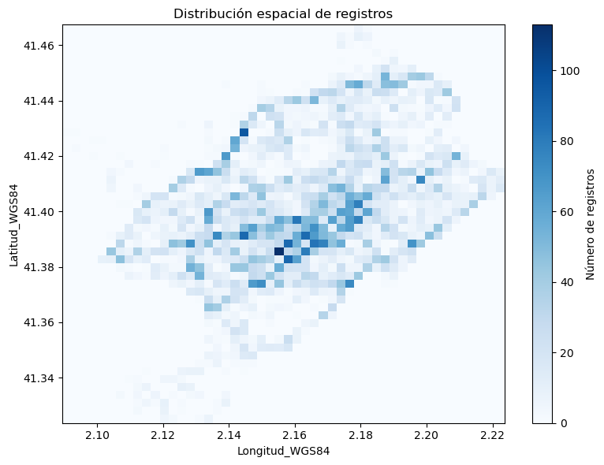

```python
# Estadísticos descriptivos
print("Estadísticos descriptivos:\n")
desc = v_numericas.describe().T
desc["mediana"] = v_numericas.median()
print(desc[["mean", "std", "min", "mediana", "max"]].round(2))

# Histogramas para numéricas excluyendo coordenadas que las tratamos después
for col in v_numericas.columns:
    if col not in ['Longitud_WGS84', 'Latitud_WGS84']:
        plt.figure(figsize=(6, 4))
        plt.hist(v_numericas[col].dropna(), bins=31, edgecolor='black')
        plt.title(f"Distribución de '{col}'")
        plt.xlabel(col)
        plt.ylabel("Frecuencia")
        plt.grid(axis='y', alpha=0.4)
        plt.tight_layout()
        plt.show()

# Histograma 2D para coordenadas
x = df['Longitud_WGS84'].dropna()
y = df['Latitud_WGS84'].dropna()

plt.figure(figsize=(8,6))
plt.hist2d(x, y, bins=50, cmap='Blues')
plt.colorbar(label='Número de registros')
plt.xlabel('Longitud_WGS84')
plt.ylabel('Latitud_WGS84')
plt.title('Distribución espacial de registros')
plt.tight_layout()
plt.show()
```

**Análisis:** comentad los resultados. Variables numéricas.

Por último, con los valores de tmed, tmin, tmax, racha, velmedia y hRmedia sí que vemos valores que destacan sobre otros pero, si pensamos con lógica no afectan tanto a la distribución, quizás sí que existe alguna relación con accidentes pero parece ser más con cómo se distribuyen los datos.

## Análisis exploratorio de los datos

En este subapartado exploraremos gráficamente la relación de los atributos descriptivos con la variable objetivo y analizaremos las diferentes correlaciones.

**Ejercicio:** usando una librería gráfica, como por ejemplo *matplotlib*, para cada una de las variables categóricas, superponed en un mismo gráfico el diagrama de barras para cada posible valor de la variable objetivo, diferenciando con distinto color según el valor de "gravedad". Añadid una leyenda para saber a qué clase corresponde cada histograma.

La finalidad es observar cómo se distribuye cada uno de los atributos en función de la clase que tengan, para poder identificar de manera visual y rápida si algunos atributos nos permiten predecir mejor que otros el valor de la variable objetivo.

Sugerencia: podéis usar el parámetro "alpha" en los gráficos para que se aprecien los dos histogramas. Sugerencia: valorad la posibilidad de utilizar la escala logarítmica en el eje "y".

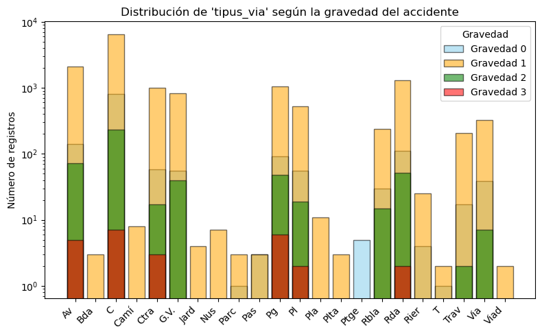

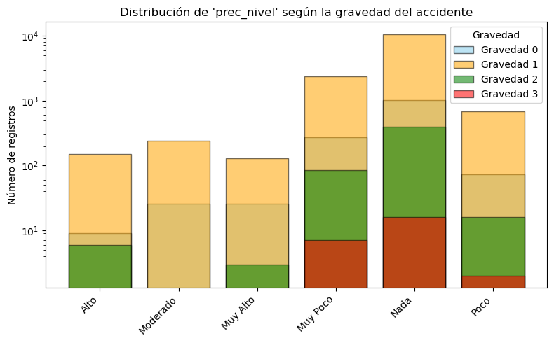

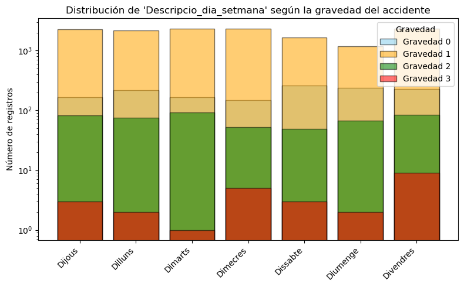

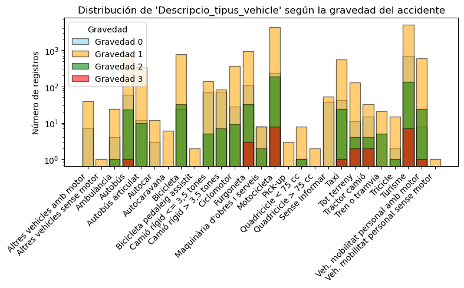

```python
# Lista de colores para las clases de Gravedad (0 a 3)
colores = ['skyblue', 'orange', 'green', 'red']

for col in v_categoricas.columns:
    plt.figure(figsize=(8,5))

    # Obtener las categorías de la variable (ordenadas)
    categorias = sorted(v_categoricas[col].dropna().unique())
    x = np.arange(len(categorias))

    for gravedad in sorted(df['Gravedad'].unique()):
        # Conteo de cada categoría para la clase gravedad
        conteos = np.array([
            ((df[col] == cat) & (df['Gravedad'] == gravedad)).sum()
            for cat in categorias
        ])

        plt.bar(x, conteos,alpha=0.55, edgecolor="black", color=colores[gravedad], label=f'Gravedad {gravedad}')

    plt.xticks(x, categorias, rotation=45, ha='right')
    plt.ylabel('Número de registros')
    plt.title(f"Distribución de '{col}' según la gravedad del accidente")
    plt.yscale('log')  # opcional
    plt.legend(title='Gravedad')
    plt.tight_layout()
    plt.show()
```

**Ejercicio:** de la misma forma que en el ejercicio anterior, superponed los histogramas para los distintos valores de "gravedad" para cada variable numérica.

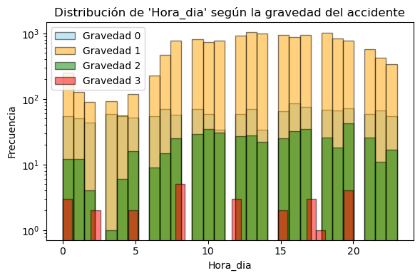

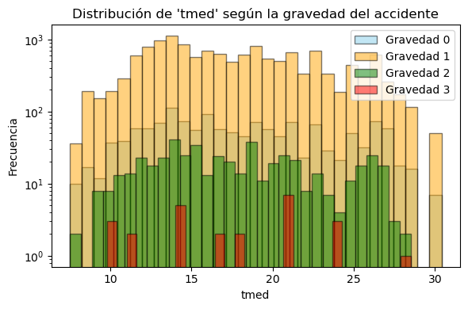

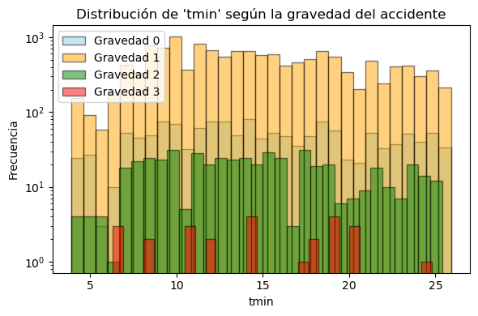

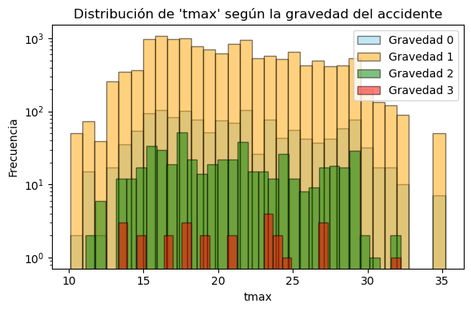

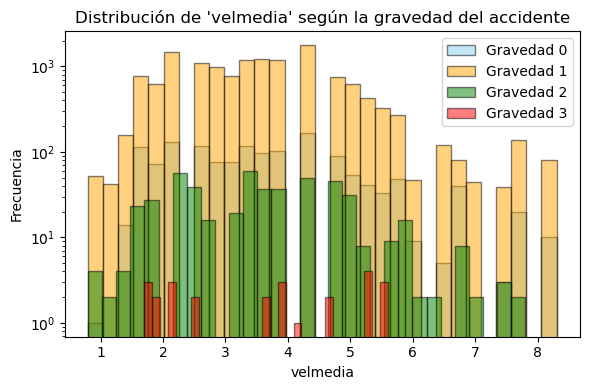

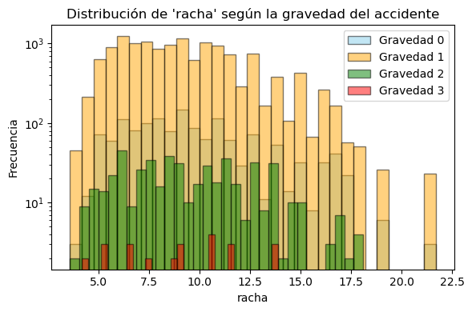

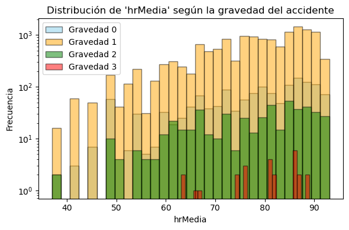

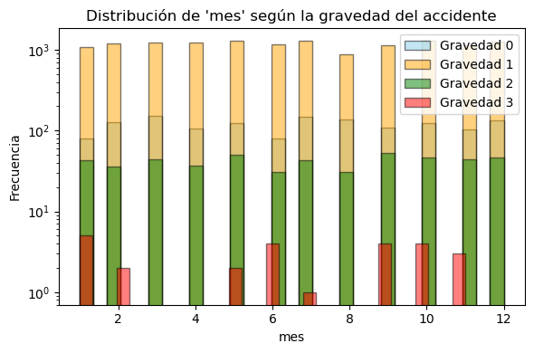

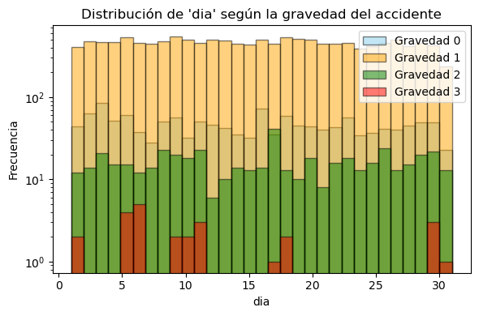

```python
for col in v_numericas.columns:
    if col not in ['Longitud_WGS84','Latitud_WGS84']:  # excluimos coordenadas
        plt.figure(figsize=(6,4))
        for gravedad, color in zip(sorted(df['Gravedad'].unique()), colores):
            subset = df[df['Gravedad']==gravedad]
            plt.hist(subset[col].dropna(), alpha=0.5, bins=31, edgecolor="black", color=color, label=f'Gravedad {gravedad}')
        plt.title(f"Distribución de '{col}' según la gravedad del accidente")
        plt.xlabel(col)
        plt.ylabel("Frecuencia")
        plt.yscale('log')
        plt.legend()
        plt.tight_layout()
        plt.show()
```

**Ejercicio:** haciendo uso de la latitud y la longitud, proyecta los distintos valores de "gravedad" en una gráfica bidimensional.

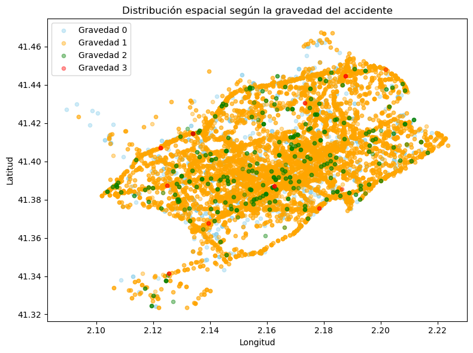

```python
plt.figure(figsize=(8,6))
for gravedad, color in zip(sorted(df['Gravedad'].unique()), colores):
    subset = df[df['Gravedad']==gravedad]
    plt.scatter(subset['Longitud_WGS84'], subset['Latitud_WGS84'],
                s=20, alpha=0.4, c=color, label=f'Gravedad {gravedad}')

plt.xlabel('Longitud')
plt.ylabel('Latitud')
plt.title('Distribución espacial según la gravedad del accidente')
plt.legend()
plt.tight_layout()
plt.show()
```

**Análisis:**  
Mirando las gráficas, ¿qué atributos parecen tener mayor influencia en el valor final de la variable objetivo? ¿Crees que con estos atributos sería suficiente para poder determinar la gravedad del accidente?

Con respecto a las numéricas si acaso la hora del día y los meses si que nos separan algo más los accidentes y podemos sacar mejor información de estos.

Por último, en cuanto a los datos espaciales no podemos ver una clara distribución donde haya mayor accidentes de un grupo conrespecto a los otros, están todos bien divididos.

**Ejercicio:** identifica y elimina los valores atípicos de las variables numéricas del conjunto de datos y repite las gráficas realizadas en el ejercicio anterior para analizar cómo podrían estar afectándonos este tipo de muestras.

Es muy importante que este paso lo realicéis en una copia del dato para no perder los valores atípicos del conjunto con el que estamos trabajando, ya que continuaremos trabajando con todas las muestras del *dataset* original en los siguientes apartados.

Nota: puedes utilizar, por ejemplo, el método IQR (Interquartile Range).

```python
# Creamos una copia del dataset original para no perder los datos originales
df_sin_outliers = df.copy()

# Eliminamos los outliers de las variables numéricas por cuantiles.
# https://online.stat.psu.edu/stat200/lesson/3/3.2
for col in v_numericas:
    Q1 = df_sin_outliers[col].quantile(0.25)
    Q3 = df_sin_outliers[col].quantile(0.75)
    IQR = Q3 - Q1
    lim_inf = Q1 - 1.5 * IQR
    lim_sup = Q3 + 1.5 * IQR
    df_sin_outliers = df_sin_outliers[
        (df_sin_outliers[col] >= lim_inf) & (df_sin_outliers[col] <= lim_sup)
    ]

print(f"Filas originales: {df.shape[0]}")
print(f"Filas después de eliminar outliers: {df_sin_outliers.shape[0]}")
```

```
Filas originales: 16193
Filas después de eliminar outliers: 15255
```

#### Si se quieren ver datos sin outliers descomentar lo siguiente

```python
# for col in v_numericas.columns:
#     if col not in ['Longitud_WGS84','Latitud_WGS84']:  # excluimos coordenadas
#         plt.figure(figsize=(6,4))
#         for gravedad, color in zip(sorted(df_sin_outliers['Gravedad'].unique()), colores):
#             subset = df_sin_outliers[df_sin_outliers['Gravedad']==gravedad]
#             plt.hist(subset[col].dropna(), alpha=0.5, bins=24, edgecolor="black", color=color, label=f'Gravedad {gravedad}')
#         plt.title(f"Distribución de '{col}' según Gravedad")
#         plt.xlabel(col)
#         plt.ylabel("Frecuencia")
#         plt.yscale('log')
#         plt.legend()
#         plt.tight_layout()
#         plt.show()
```

**Análisis:** explica qué ocurre.

Al quitar outliers de esta manera digamos que estamos definiendo una boxplot de los datos, con la mediana en el centro y cuartiles del 25% y 75%.

Con este método eliminamos valores que estén alejados un 1.5 veces el valor intercuartílico, el IQR que se calcula arriba, por lo que valores atípicos desaparecen. Al mirar las gráficas, lo he comentado para no llenar mucho el notebook, se pueden ver como los valores de la temperatura, humedad y los referentes al tiempo de más a los extremos se han eliminado.

Con esto conseguimos eliminar datos atípicos que puedan estropearnos el análisis y disminuir un poco los datos.

**Ejercicio:** calculad y mostrad la correlación entre las variables numéricas.

```python
# Matriz de correlación de las variables numéricas
corr_matrix = v_numericas.corr()

# Mostrar la matriz numérica
print("Matriz de correlación:")
display(corr_matrix)
```

```
Matriz de correlación:
```

|  | Longitud_WGS84 | Latitud_WGS84 | Hora_dia | tmed | tmin | tmax | velmedia | racha | hrMedia | mes | dia |
| --- | --- | --- | --- | --- | --- | --- | --- | --- | --- | --- | --- |
| Longitud_WGS84 | 1.000000 | 0.392744 | -0.023048 | 0.021778 | 0.020467 | 0.022742 | -0.016294 | -0.037008 | 0.004916 | 0.003466 | 0.004641 |
| Latitud_WGS84 | 0.392744 | 1.000000 | 0.000400 | 0.001591 | 0.006933 | -0.004260 | -0.016469 | -0.022088 | 0.022962 | -0.005282 | -0.002497 |
| Hora_dia | -0.023048 | 0.000400 | 1.000000 | -0.018164 | -0.017406 | -0.018448 | 0.012213 | 0.026580 | -0.025415 | -0.009062 | 0.009809 |
| tmed | 0.021778 | 0.001591 | -0.018164 | 1.000000 | 0.986777 | 0.984169 | 0.234428 | 0.013260 | 0.169086 | 0.285616 | 0.025472 |
| tmin | 0.020467 | 0.006933 | -0.017406 | 0.986777 | 1.000000 | 0.942520 | 0.259298 | 0.009905 | 0.248885 | 0.268959 | 0.043798 |
| tmax | 0.022742 | -0.004260 | -0.018448 | 0.984169 | 0.942520 | 1.000000 | 0.199770 | 0.016211 | 0.075733 | 0.293879 | 0.003291 |
| velmedia | -0.016294 | -0.016469 | 0.012213 | 0.234428 | 0.259298 | 0.199770 | 1.000000 | 0.635700 | 0.044450 | 0.019997 | 0.073706 |
| racha | -0.037008 | -0.022088 | 0.026580 | 0.013260 | 0.009905 | 0.016211 | 0.635700 | 1.000000 | -0.249106 | 0.053372 | -0.025800 |
| hrMedia | 0.004916 | 0.022962 | -0.025415 | 0.169086 | 0.248885 | 0.075733 | 0.044450 | -0.249106 | 1.000000 | 0.017821 | 0.074784 |
| mes | 0.003466 | -0.005282 | -0.009062 | 0.285616 | 0.268959 | 0.293879 | 0.019997 | 0.053372 | 0.017821 | 1.000000 | 0.014648 |
| dia | 0.004641 | -0.002497 | 0.009809 | 0.025472 | 0.043798 | 0.003291 | 0.073706 | -0.025800 | 0.074784 | 0.014648 | 1.000000 |

**Análisis:** comenta los resultados.

Las variables de temperaturas, tmed, tmin y tmax están fuertemente relacionadas, prácticamente representan lo mismo la tener valores de correlación muy cercanos a 1.

Algo parecido con velmedia y racha, tienen una correlación positiva alta, pero no tanto como los otros. Cuanto más velocidad media del viento mayores suelen ser las rachas.

A partir de aquí no hay tanta correlación pero algo podemos decir:

- Hay una correlación negativa donde, cuando hay rachas más fuertes, la humedad suele ser menor.
- Hay una pequeña correlación positiva de, a mayor temperatura, mayor humedad media.
- Hay un última pequeña correlación donde nos indican que días con más viento tienden a ser más calientes.

Estos último hay que tener cuidado ya que hay que saber que son datos de todo el año y varían mucho las condiciones climáticas, además que en una zona de costa como barcelona difiere mucho de otros lugares del mundo sin mar cerca.

# Preprocesado de los datos (1 punto)

Una vez analizados los atributos descriptivos, es el momento de prepararlos para que nos sean útiles de cara a predecir valores.

En este apartado:

- Transformaremos los atributos descriptivos categóricos en variables numéricas para poder utilizarlas en cualquier tipo de modelo.
- Estandarizaremos los valores de los atributos descriptivos numéricos para que sus escalas no sean muy diferentes.
- Separaremos el conjunto de datos original en dos subconjuntos: entrenamiento y test.

**Ejercicio:** transforma los atributos descriptivos categóricos en variables numéricas aplicando la técnica que mejor creas conveniente.

```python
# Podemos estandarizar las varaibles numéricas directamente teniendo en cuenta la definición de estandarización.
# Para esto tenemos que hacer que la media sea 0 y la desviación estándar sea 1.
for col in v_numericas:
    df[col] = (df[col] - df[col].mean()) / df[col].std()
```

```python
from sklearn.preprocessing import OrdinalEncoder

# Creamos una copia para no modificar el dataset original
df_preHot = df.copy()

# En prec_nivel, como hay una jerarquía clara usamos un OrdinalEncoder
# https://scikit-learn.org/stable/modules/generated/sklearn.preprocessing.OrdinalEncoder.html
encoder = OrdinalEncoder(categories=[['Poco', 'Nada', 'Muy Alto', 'Moderado', 'Alto', 'Muy Poco']])
df['prec_nivel'] = encoder.fit_transform(df[['prec_nivel']])

# En las otras dos categóricas, como no hay jerarquias podemos usar one hot encoding aunque genere nuevas variables
categoricas = categoricas.remove('prec_nivel')
df = pd.get_dummies(df, columns=categoricas, drop_first=True)

print("Dimensiones después del One-Hot Encodin:", df.shape)
print("Dimensiones antes del One-Hot Encoding:", df_preHot.shape)

# Sacamos las nuevas variables creadas que eran categóricas
new_categoricas = [col for col in df.columns if col not in df_preHot.columns]
new_categoricas.append('prec_nivel')
```

```
Dimensiones después del One-Hot Encodin: (16193, 66)
Dimensiones antes del One-Hot Encoding: (16193, 16)
```

**Ejercicio:** estandariza todos los atributos descriptivos, que ahora son numéricos. Este será el nuevo conjunto de atributos descriptivos con el que trabajaremos desde ahora.

Sugerencia: utilizad "StandardScaler" de *preprocessing*.

```python
# https://scikit-learn.org/stable/modules/generated/sklearn.preprocessing.StandardScaler.html
# Para estandarizar los descriptivos con StandarScaler sería hacer lo siguiente.
from sklearn.preprocessing import StandardScaler

# Inicializar el escalador
scaler = StandardScaler()

# Transformar
df[new_categoricas] = scaler.fit_transform(df[new_categoricas])
```

**Ejercicio:** separa los atributos descriptivos escalados y la variable objetivo en los subconjuntos de entrenamiento y test.

Sugerencia: para separar entre train y test podéis usar "train_test_split" de sklearn.

```python
# https://scikit-learn.org/stable/modules/generated/sklearn.model_selection.train_test_split.html
y = df["Gravedad"]
X = df.drop("Gravedad", axis=1)

# Dividir en 80% train, 20% test
X_train, X_test, y_train, y_test = train_test_split(
    X, y,
    test_size=0.2,          # 20% para test
    random_state=seed,      # semilla del principio
    stratify=y
)
```

**Debate:** dentro de los Foros de discusión se creará un hilo donde debatiremos si la decisión de transformar el conjunto de datos (estandarización) antes de realizar la separación del conjunto de datos en los subconjuntos de entrenamiento y test es o no una buena idea.

https://aula.uoc.edu/courses/61393/discussion_topics/1466793?entry_id=5077790

**Análisis:** en este ejercicio hemos estandarizado los valores de los atributos descriptivos para que sus escalas no sean muy diferentes. ¿Qué nos aporta estandarizar los atributos descriptivos? ¿hay alguna situación o escenario en la que sea imprescindible?

La estandarización de los atributos descriptivos sirve para que todos los atributos se muevan en intervalos parecidos. Así, da igual la magnitud inicial de tus datos, si tienes atributos que se mueven por el rango de los millones y otros de las decenas, al estandarizar todos los atributos tendrán una media de 0 y desviación estandar 1.

Esto sirve sobre todo en modelos de aprendizaje automático basado en distancias, ya que, sino estandarizamos, el modelo le daría muchísimo más peso a valores con magnitudes más altas, sean o no más descriptivas que otras.

# Reducción de la dimensionalidad (2 puntos)

En este apartado retomaremos el análisis gráfico de distribución de la variable objetivo a lo largo de las muestras del conjunto de datos. En el segundo apartado pudimos observar si las variables descriptivas por separado eran muy prometedoras o no de cara a la predicción. Aquí vamos a intentar determinar si su combinación puede ayudarnos a determinar la gravedad del accidente de mejor manera que utilizando los atributos por separado. Con este propósito, vamos a reducir la dimensionalidad del problema a solamente dos atributos, que serán la proyección de los atributos descriptivos originales, y observaremos de qué manera se distribuyen las muestras en función de su valor objetivo.

**Ejercicio:**

- Aplicad el método de reducción de la dimensionalidad Principal Component Analysis (PCA) para reducir a 2 dimensiones el dataset entero con todas las *features*.
- Con el objetivo de visualizar si es posible predecir eficientemente el valor de la variable objetivo con este método, generad un gráfico en 2D con el resultado del PCA utilizando una escala de colores que permita distinguir de forma sencilla si los valores altos o bajos se acumulan más o menos en determinadas zonas.

NOTA: Tened cuidado, no incluyáis la variable objetivo en la reducción de dimensionalidad. Queremos explicar la variable objetivo en función del resto de variables reducidas a dos dimensiones.

Sugerencia: no es necesario que programéis el algoritmo de PCA, podéis usar la implementación disponible en la librería de *scikit-learn*.

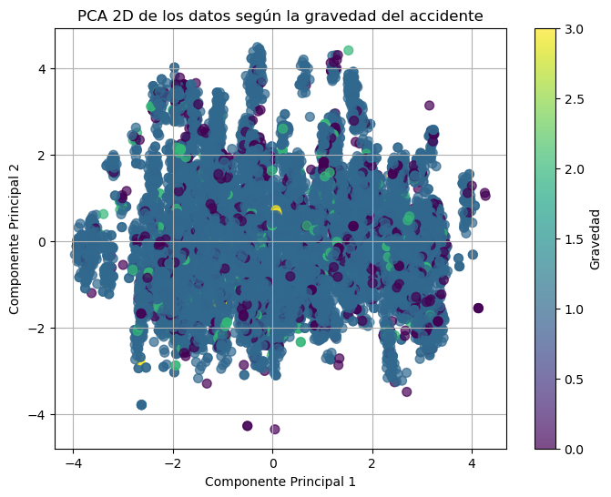

```python
# Aplicar PCA para reducir a 2 dimensiones
pca = PCA(n_components=2)
X_pca = pca.fit_transform(X)

# Crear un DataFrame con las dos componentes principales
df_pca = pd.DataFrame(X_pca, columns=['Dim1', 'Dim2'])
df_pca['Gravedad'] = y.values

# Graficar los resultados
plt.figure(figsize=(8,6))
scatter = plt.scatter(
    df_pca['Dim1'], df_pca['Dim2'],
    c=df_pca['Gravedad'],
    cmap='viridis',
    s=50,
    alpha=0.7
)
plt.colorbar(scatter, label='Gravedad')
plt.xlabel('Componente Principal 1')
plt.ylabel('Componente Principal 2')
plt.title('PCA 2D de los datos según la gravedad del accidente')
plt.grid(True)
plt.show()
```

**Ejercicio:**

- Repetid la reducción de dimensionalidad, pero en este caso usando TSNE. Podéis encontrar más información acerca de este algoritmo en el siguiente enlace: https://distill.pub/2016/misread-tsne/
- Al igual que antes, generad un gráfico en 2D con el resultado del TSNE utilizando una escala degradada de colores para la variable objetivo ("y"), con el fin de visualizar si es posible predecir eficientemente el valor de la variable objetivo con este método.

Sugerencia: no es necesario que programéis el algoritmo TSNE, podéis usar la implementación disponible en la librería de *scikit-learn*.  
Sugerencia: a parte de especificar el número de componentes, probad a usar los parámetros "learning_rate" y "perplexity".

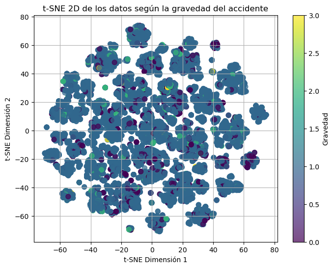

```python
# Aplicar t-SNE para reducir a 2 D
tsne = TSNE(
    n_components=2,
    learning_rate=100,
    perplexity=40,
    random_state=seed
)
X_tsne = tsne.fit_transform(X)

# Crear DataFrame para la gráfica 2D
df_tsne = pd.DataFrame(X_tsne, columns=['Dim1', 'Dim2'])
df_tsne['Gravedad'] = y.values

plt.figure(figsize=(8,6))
scatter = plt.scatter(
    df_tsne['Dim1'], df_tsne['Dim2'],
    c=df_tsne['Gravedad'],
    cmap='viridis',
    s=50,
    alpha=0.7
)
plt.colorbar(scatter, label='Gravedad')
plt.xlabel('t-SNE Dimensión 1')
plt.ylabel('t-SNE Dimensión 2')
plt.title('t-SNE 2D de los datos según la gravedad del accidente')
plt.grid(True)
plt.show()
```

**Análisis:** observando los dos gráficos, ¿crees que ha funcionado bien la reducción de dimensionalidad? ¿Crees que será útil para predecir el valor de la variable objetivo? ¿Cuál de los dos métodos ha funcionado mejor? ¿Por qué obtenemos resultados tan diferentes?

A mi parecer, en el PCA no consigo distinguir zonas donde exista un mayor índice de gravedad de accidentes, están todos los datos mezclados sin un patron claro.

Pasa lo mismo casi con t-SNE aunque si se consiguen ver algunas regiones onde hay una mayor cantidad de puntos más oscuros que indica una menor gravedad.

Sin embargo, a priori, viendo ambas gráficas no me parece que haya funcionado muy bien la reducción a 2 Dimensiones con estos dos métodos. No sé si por los atributos descriptivos o por el tipos de dataset elegido.

**Pregunta:** ¿qué opinas de TSNE como opción para reducir la dimensionalidad? ¿Qué te parece que sólo tenga el método "fit_transform" pero no tenga "transform"? ¿Conoces alguna otra opción que, con unas prestaciones similares, evite los problemas que tiene TSNE?

No es una técnica perfecta, si que, al menos en nuestro ejemplo es algo mejor que el PCA pero habría que mirar más valores o técnicas para mejorarlo.

t-SNE no tiene transform por las técnicas que utiliza, en vez de ser un método lineal como PCA, t-SNE busca relaciones entre datos vecinos. Por lo que no puedes realizar primero un fit de los datos para que los parámetros aprendan y después transformarlos sino que tienes que hacerlo en un solo paso por cómo está echo el algoritmo.

He intentado buscar otros métodos y me he encontrado con alguna pregunta de foros de Reddit como este: https://www.reddit.com/r/datascience/comments/wy1rmk/pca_vs_umap_vs_tsne_on_a_very_layman_level_what/?tl=es-es

Al menos en este foro, además de hablar de PCA y t-SNE hablan sobre un tercer método que parece que también es muy utilizado y bueno, el cual es el UMAP. https://umap-learn.readthedocs.io/en/latest/